# analise_acerto

## Quais as características dos usuários winback?

A Acerto é uma empresa de Winback, ou seja, somos especialistas em reconquistar clientes desengajados e recuperar receitas perdidas. Para isso, podemos expor consumidores a estratégias diferentes esperando sua conversão.

O case abaixo está neste contexto, em que escolhemos os melhores consumidores a serem acionados, com base no resultado do acionamento de outros consumidores.

### Objetivo

Crie um script com um modelo preditivo simples utilizando esses dados.

### Passos

- Separe a base em treino e teste (25% teste).
- Desenvolva o modelo.
- Retorne a acurácia de seu modelo.
- Gere uma lista com os 1.000 melhores consumidores a serem acionados.

Observação: use o pagamento como variável dependente.

### Outras informações

Em conversa, foi exposto como a forma de abordar o cliente de maneira mais específica ajuda na conversão do cliente. Dessa forma, um modelo puramente preditivo, embora provavelmente apresente uma acurácia maior, não necessariamente ajuda na abordagem do cliente para sua conversão.

Uma metodologia puramente preditiva pode ajudar a entender uma carteira e seu potencial de winback. No entanto, a partir do momento que o objetivo é fazer a conversão, é importante entender quais são os fatores que fazem aquele indivíduo ter um alto potencial de conversão.

```python
import numpy as np
import pandas as pd
import matplotlib.pyplot as plt
import seaborn as sns
from dateutil.relativedelta import relativedelta
import datetime as dt
```

```python
train = pd.read_csv("1.consumidores_treinamento (1).csv", sep = ";")
teste = pd.read_csv("1.consumidores_previsão (1).csv", sep = ';')
```

```python
train.info()
```

```
<class 'pandas.core.frame.DataFrame'>
RangeIndex: 10000 entries, 0 to 9999
Data columns (total 12 columns):
 #   Column                Non-Null Count  Dtype
---  ------                --------------  -----
 0   consumidor_id         5000 non-null   float64
 1   email                 5000 non-null   object
 2   renda                 5000 non-null   object
 3   data_nascimento       5000 non-null   object
 4   acessos               5000 non-null   float64
 5   primeiro_login        2928 non-null   object
 6   visualizacoes_divida  2928 non-null   float64
 7   realizou_pagamento    2928 non-null   float64
 8   Unnamed: 8            0 non-null      float64
 9   Unnamed: 9            0 non-null      float64
 10  Unnamed: 10           0 non-null      float64
 11  Unnamed: 11           0 non-null      float64
dtypes: float64(8), object(4)
memory usage: 937.6+ KB
```

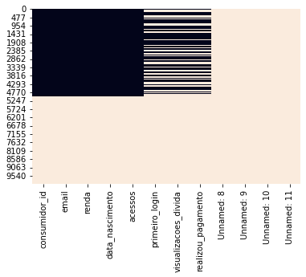

```python
sns.heatmap(train.isnull(), cbar=False)
```

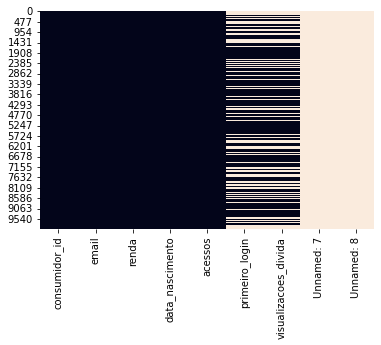

```python
sns.heatmap(teste.isnull(), cbar=False)
```

### Tratamento de dados

```python
train_to_drop = list(train.filter(regex='Unnamed'))
teste_to_drop = list(teste.filter(regex="Unnamed"))
```

```python
train.drop(train_to_drop, axis = 1, inplace = True)
teste.drop(teste_to_drop, axis = 1, inplace = True)
```

```python
train.dropna(how='all', inplace=True)
```

```python
train['provedor'] = train['email'].apply(lambda x: x.split("@")[1]).apply(lambda x: x.split(".")[0])
teste['provedor'] = teste['email'].apply(lambda x: x.split("@")[1]).apply(lambda x: x.split(".")[0])
```

```python
train.drop(['email'], axis=1, inplace=True)
teste.drop(['email'], axis=1, inplace=True)
```

```python
train['nascimento'] = pd.to_datetime(train['data_nascimento'], format="%d/%m/%Y")
teste['nascimento'] = pd.to_datetime(teste['data_nascimento'], format="%d/%m/%Y")
```

```python
train['primeiro_login'] = pd.to_datetime(train['primeiro_login'], format="%d/%m/%Y")
teste['primeiro_login'] = pd.to_datetime(teste['primeiro_login'], format="%d/%m/%Y")
```

```python
train['idade'] = [relativedelta(pd.Timestamp('now'), d).years for d in train['nascimento']]
teste['idade'] = [relativedelta(pd.Timestamp('now'), d).years for d in teste['nascimento']]
```

```python
train['meses_desde_primeiro_login'] = (pd.Timestamp('now') - train['primeiro_login']).dt.days / 30
train.loc[train['meses_desde_primeiro_login'].isnull(), 'meses_desde_primeiro_login'] = -1

teste['meses_desde_primeiro_login'] = (pd.Timestamp('now') - teste['primeiro_login']).dt.days / 30
teste.loc[teste['meses_desde_primeiro_login'].isnull(), 'meses_desde_primeiro_login'] = -1
```

```python
train.loc[train['visualizacoes_divida'].isnull(), 'visualizacoes_divida'] = -1
teste.loc[teste['visualizacoes_divida'].isnull(), 'visualizacoes_divida'] = -1
```

```python
train.drop(['data_nascimento', 'primeiro_login', 'nascimento'], axis=1, inplace=True)
teste.drop(['data_nascimento', 'primeiro_login', 'nascimento'], axis=1, inplace=True)
```

```python
train.loc[train['realizou_pagamento'].isnull(), 'realizou_pagamento'] = 0
```

### Análise exploratória básica

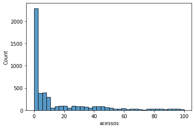

```python
sns.histplot(train['acessos'])
plt.show()
```

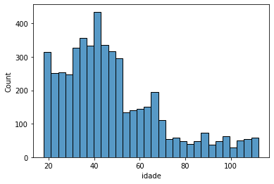

```python
sns.histplot(train['idade'])
plt.show()
```

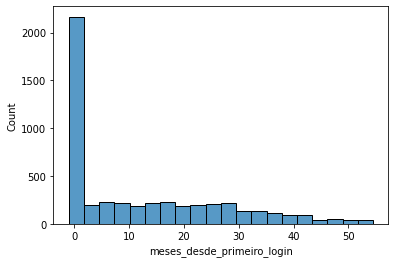

```python
sns.histplot(train['meses_desde_primeiro_login'])
plt.show()
```

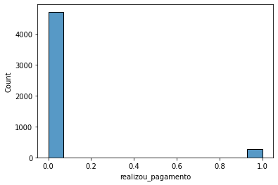

```python
sns.histplot(train['realizou_pagamento'])
plt.show()
```

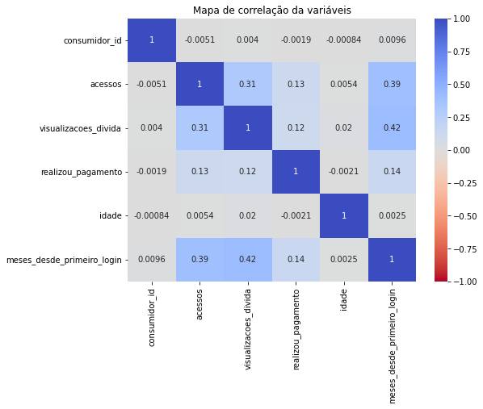

```python
corr = train.corr()
plt.figure(figsize=(8,6))
sns.heatmap(corr, cmap = 'coolwarm_r', vmin = -1, vmax = 1, annot=True)
plt.title('Mapa de correlação da variáveis')
plt.show()
```

### Balanceamento de base

Para lidar com o desbalanceamento de base, vou remover aqueles que não tiveram nenhum acesso. Além disso, vou realizar um *undersampling* na categoria de maior número para equilibrar o número de não pagantes com o número de pagantes.

```python
train['realizou_pagamento'].value_counts()
```

```
0.0    4724
1.0     276
Name: realizou_pagamento, dtype: int64
```

```python
train_acesso = train[train['acessos'] != 0]
```

```python
train_acesso['realizou_pagamento'].value_counts()
```

```
0.0    2652
1.0     276
Name: realizou_pagamento, dtype: int64
```

```python
X = train_acesso.drop(['realizou_pagamento', 'consumidor_id'], axis = 1)
y = train_acesso['realizou_pagamento']
```

```python
from imblearn.under_sampling import RandomUnderSampler
```

```python
undersample = RandomUnderSampler(random_state=42)
X, y = undersample.fit_resample(X, y)
```

### Aplicação de algoritmo

Para o modelo final, teremos muito menos observações para realizar as comparações. No entanto, um modelo com todos os dados traria uma acuracidade ilusória. Quando a maior parte dos dados é de uma categoria em particular, o modelo pode se tornar "preguiçoso" e fazer a previsão que todos pertencem ao maior grupo. Isso manterá a acuracidade alta, mas não ajudará no problema de negócio principal, que é identificar quem são aqueles com maior probabilidade de gerar conversão.

Com a base balanceada e sabendo dos problemas que uma base não balanceada poderia trazer, vamos seguir para a separação da base em treino e teste.

Em seguida a aplicação do modelo catboost, que é semelhante a um modelo de random forest.

```python
from sklearn.model_selection import train_test_split
```

```python
X_train, X_test, y_train, y_test = train_test_split(X, y, test_size=0.25, random_state=42)
```

```python
from catboost import CatBoostClassifier
from sklearn.metrics import classification_report, confusion_matrix
import shap
```

```python
cat_feat_bool = X_train.dtypes == object
cat_feat_position = [i for i, x in enumerate(cat_feat_bool) if x]
```

```python
clf = CatBoostClassifier(iterations=500)
clf.fit(X_train, y_train,
        cat_features=cat_feat_position,
        verbose=False,
)
```

```
<catboost.core.CatBoostClassifier at 0x262cac39a50>
```

### Checando principais métricas

```python
y_pred = clf.predict(X_test)
```

```python
confusion = confusion_matrix(y_test, y_pred)
print('Confusion Matrix\n')
print(confusion)
```

```
Confusion Matrix

[[39 34]
 [28 37]]
```

```python
print('\nClassification Report\n')
print(classification_report(y_test, y_pred))
```

```
Classification Report

              precision    recall  f1-score   support

         0.0       0.58      0.53      0.56        73
         1.0       0.52      0.57      0.54        65

    accuracy                           0.55       138
   macro avg       0.55      0.55      0.55       138
weighted avg       0.55      0.55      0.55       138
```

Aplicando a predição para a base balanceada, vemos que há um ganho muito pequeno. No entanto, ao aplicar o entendimento gerado pelo tratamento de bases, a acuracidade final pode se tornar maior, já que há uma grande parte da base que é sabido que o resultado final vai ser de não conversão.

A previsão de não conversão é simples. Todos aqueles que não tiveram nenhum acesso, também não geraram conversão. No entanto, dentre aqueles que tiveram acesso, o algoritmo tem dificuldade de fazer a diferenciação de ser ou não convertido.

```python
y_pred_total = clf.predict(train.drop(['realizou_pagamento', 'consumidor_id'], axis = 1))
train['pred'] = y_pred_total
train['pred'] = np.where(train['acessos'] == 0, 0, train['pred'])
```

```python
print('\nClassification Report\n')
print(classification_report(train['realizou_pagamento'], train['pred']))
```

```
Classification Report

              precision    recall  f1-score   support

         0.0       0.98      0.72      0.83      4724
         1.0       0.14      0.76      0.23       276

    accuracy                           0.73      5000
   macro avg       0.56      0.74      0.53      5000
weighted avg       0.93      0.73      0.80      5000
```

### Variáveis de maior impacto

```python
explainer = shap.TreeExplainer(clf)
shap_values = explainer(X_train)
```

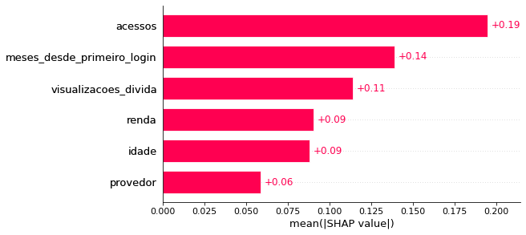

```python
shap.plots.bar(shap_values)
```

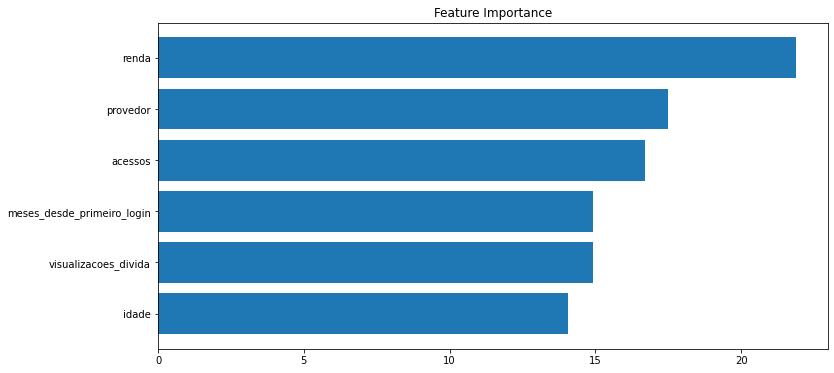

```python
feature_importance = clf.feature_importances_
sorted_idx = np.argsort(feature_importance)
fig = plt.figure(figsize=(12, 6))
plt.barh(range(len(sorted_idx)), feature_importance[sorted_idx], align='center')
plt.yticks(range(len(sorted_idx)), np.array(X_test.columns)[sorted_idx])
plt.title('Feature Importance')
```

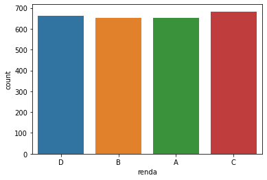

```python
sns.countplot(x = train_acesso[train_acesso['realizou_pagamento']==0]['renda'])
```

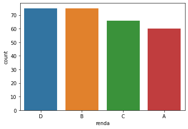

```python
sns.countplot(x = train_acesso[train_acesso['realizou_pagamento']==1]['renda'])
```

### Extraindo os 1000 melhores da base final

Aplicando predição na base de teste e retornando os 1000 melhores clientes para tentativa de wib=nback

```python
y_pred_teste = clf.predict_proba(teste.drop(['consumidor_id'], axis = 1))
```

```python
teste['prob_winback'] = list(zip(*y_pred_teste))[1]
```

```python
teste1000 = teste.sort_values(by = ['prob_winback'], axis=0, ascending = False).head(1000).reset_index()
```

```python
teste1000
```

|  | index | consumidor_id | renda | acessos | visualizacoes_divida | provedor | idade | meses_desde_primeiro_login | prob_winback |
| --- | --- | --- | --- | --- | --- | --- | --- | --- | --- |
| 0 | 3472 | 8473 | D | 36 | 96.0 | provedor_a | 36 | 6.300000 | 0.788633 |
| 1 | 117 | 5118 | B | 32 | 8.0 | provedor_b | 22 | 17.033333 | 0.773710 |
| 2 | 7472 | 12473 | B | 40 | 10.0 | provedor_b | 19 | 19.400000 | 0.764994 |
| 3 | 567 | 5568 | B | 39 | 8.0 | provedor_b | 89 | 1.233333 | 0.749732 |
| 4 | 8554 | 13555 | D | 89 | 88.0 | provedor_c | 69 | 1.866667 | 0.746848 |
| ... | ... | ... | ... | ... | ... | ... | ... | ... | ... |
| 995 | 4599 | 9600 | A | 18 | 31.0 | provedor_c | 42 | 15.066667 | 0.589612 |
| 996 | 6042 | 11043 | A | 4 | 31.0 | provedor_a | 39 | 7.066667 | 0.589598 |
| 997 | 4499 | 9500 | A | 43 | 7.0 | provedor_b | 21 | 39.300000 | 0.589346 |
| 998 | 1577 | 6578 | B | 4 | 17.0 | provedor_c | 81 | 1.133333 | 0.589294 |
| 999 | 3973 | 8974 | D | 8 | 37.0 | provedor_c | 28 | 2.400000 | 0.589263 |

1000 rows × 9 columns

```python
teste1000.to_csv(path_or_buf="lista1000.csv", index=False)
```